# Compulsory exercise 1

TMA4268 Statistical Learning V2021

Dilawar Mahmood

23 mai, 2021

# Problem 1

## c) See notes.

```r
id <- "1X_8OKcoYbng1XvYFDirxjEWr7LtpNr1m" # google file ID
values <- dget(sprintf("https://docs.google.com/uc?id=%s&export=download", id))
X = values$X
dim(X)
```

```
## [1] 100  81
```

```r
x0 = values$x0
dim(x0)
```

```
## [1] 81  1
```

```r
beta=values$beta
dim(beta)
```

```
## [1] 81  1
```

```r
sigma=values$sigma
sigma
```

```
## [1] 0.5
```

## d)

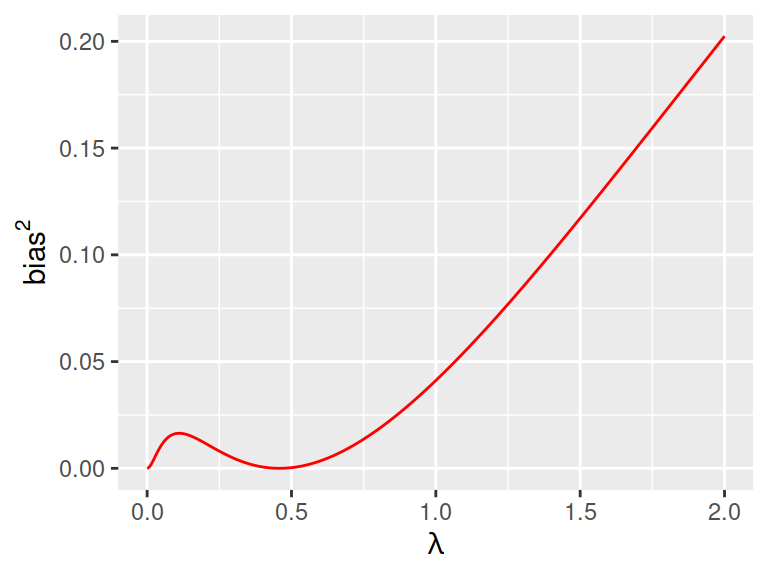

```r
library(ggplot2)
bias = function(lambda, X, x0, beta) {
    p = ncol(X)
    value = (t(x0) %*% solve(t(X) %*% X + lambda * diag(p)) %*% t(X) %*% X %*% beta - t(x0) %*% beta)^2
    return(value)
}
lambdas = seq(0, 2, length.out = 500)
BIAS = rep(NA, length(lambdas))
for (i in 1:length(lambdas)) BIAS[i] = bias(lambdas[i], X, x0, beta)
dfBias = data.frame(lambdas = lambdas, bias = BIAS)
ggplot(dfBias, aes(x = lambdas, y = bias)) + geom_line(color = "red") + xlab(expression(lambda)) +
    ylab(expression(bias^2))
```

## e

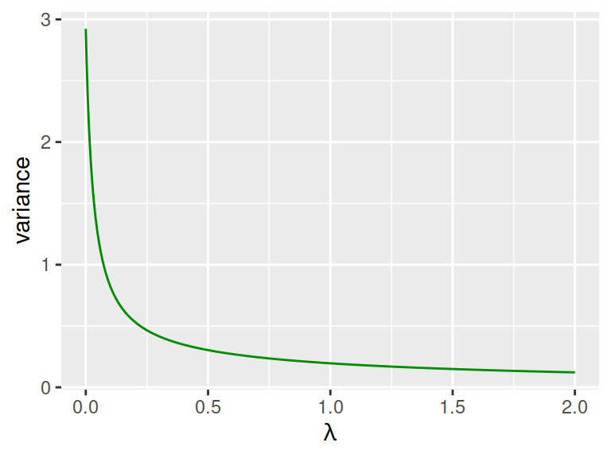

```r
variance = function(lambda, X, x0, sigma) {
  p = ncol(X)
  inv = solve(t(X) %*% X + lambda * diag(p))
  value = sigma^2 * t(x0) %*% inv %*% t(X) %*% X %*% inv %*% x0
  return(value)
}
lambdas = seq(0, 2, length.out = 500)
VAR = rep(NA, length(lambdas))
for (i in 1:length(lambdas)) VAR[i] = variance(lambdas[i], X, x0, sigma)
dfVar = data.frame(lambdas = lambdas, var = VAR)
ggplot(dfVar, aes(x = lambdas, y = var)) + geom_line(color = "green4") + xlab(expression(lambda)) + ylab("variance")
```

## f)

```r
exp_mse = BIAS + VAR + sigma^2
lambdas[which.min(exp_mse)]
```

```
## [1] 0.993988
```

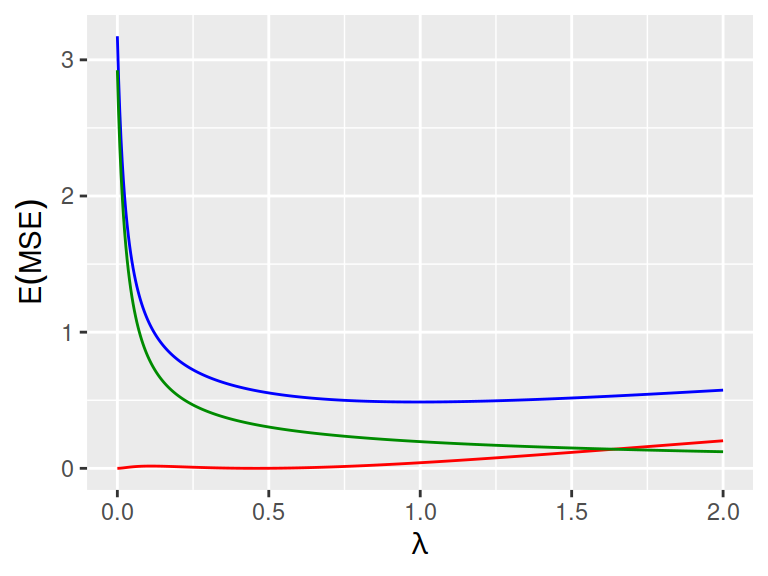

```r
dfAll = data.frame(lambda = lambdas, bias = BIAS, var = VAR, exp_mse = exp_mse)
ggplot(dfAll) + geom_line(aes(x = lambda, y = exp_mse), color = "blue") + geom_line(aes(x = lambda,
    y = bias), color = "red") + geom_line(aes(x = lambda, y = var), color = "green4") +
    xlab(expression(lambda)) + ylab(expression(E(MSE)))
```

# Problem 2

```r
# read file
id <- "1yYlEl5gYY3BEtJ4d7KWaFGIOEweJIn__"  # google file ID
d.corona <- read.csv(sprintf("https://docs.google.com/uc?id=%s&export=download",
    id), header = T)
```

## a)

The number of deceased and non-deceased:

```r
table(d.corona$deceased)
```

```
##
##    0    1
## 1905  105
```

For each country the number of males and females:

```r
table(d.corona$country, d.corona$sex)
```

```
##
##             female male
##   France        60   54
##   indonesia     30   39
##   japan        120  174
##   Korea        879  654
```

The number of deceased and non-deceased for each sex:

```r
table(d.corona$deceased, d.corona$sex)
```

```
##
##     female male
##   0   1046  859
##   1     43   62
```

The number of deceased and non-deceased in France, separate for each sex:

```r
france = d.corona[which(d.corona$country == "France"), ]
table(france$deceased, france$sex)
```

```
##
##     female male
##   0     55   43
##   1      5   11
```

## b)

```r
r.glm <- glm(deceased ~ sex + age + country, d.corona, family = "binomial")
summary(r.glm)
```

```
##
## Call:
## glm(formula = deceased ~ sex + age + country, family = "binomial",
##     data = d.corona)
##
## Deviance Residuals:
##     Min       1Q   Median       3Q      Max
## -0.9050  -0.3508  -0.2761  -0.2144   3.1165
##
## Coefficients:
##                   Estimate Std. Error z value Pr(>|z|)
## (Intercept)      -3.993485   0.462190  -8.640  < 2e-16 ***
## sexmale           0.626068   0.209045   2.995  0.00275 **
## age               0.027134   0.004736   5.729 1.01e-08 ***
## countryindonesia -0.411855   0.550051  -0.749  0.45400
## countryjapan     -1.343383   0.417196  -3.220  0.00128 **
## countryKorea     -0.773895   0.307980  -2.513  0.01198 *
## ---
## Signif. codes:  0 '***' 0.001 '**' 0.01 '*' 0.05 '.' 0.1 ' ' 1
##
## (Dispersion parameter for binomial family taken to be 1)
##
##     Null deviance: 824.32  on 2009  degrees of freedom
## Residual deviance: 766.16  on 2004  degrees of freedom
## AIC: 778.16
##
## Number of Fisher Scoring iterations: 6
```

```r
anova(r.glm, test="Chisq")
```

```
## Analysis of Deviance Table
##
## Model: binomial, link: logit
##
## Response: deceased
##
## Terms added sequentially (first to last)
##
##
##         Df Deviance Resid. Df Resid. Dev  Pr(>Chi)
## NULL                     2009     824.32
## sex      1    7.785      2008     816.54  0.005268 **
## age      1   39.311      2007     777.23 3.613e-10 ***
## country  3   11.063      2004     766.16  0.011390 *
## ---
## Signif. codes:  0 '***' 0.001 '**' 0.01 '*' 0.05 '.' 0.1 ' ' 1
```

### i)

```r
coefs <- summary(r.glm)$coef[, 1]
eta <- coefs["(Intercept)"] + coefs["sexmale"] + 75 * coefs["age"] + coefs["countryKorea"]

(prob <- exp(eta) / (1 + exp(eta)))
```

```
## (Intercept)
##   0.1084912
```

### ii)

Yes, because estimate for `sexmale` is positive and $p=0.00275$.

### iii)

Yes, because $p=0.011390$.

### iv)

```r
exp(coefs["age"] * 10)
```

```
##      age
## 1.311724
```

## c)

### i)

```r
mod2 = glm(deceased ~ sex * age + country, d.corona, family = "binomial")
summary(mod2)
```

```
##
## Call:
## glm(formula = deceased ~ sex * age + country, family = "binomial",
##     data = d.corona)
##
## Deviance Residuals:
##     Min       1Q   Median       3Q      Max
## -0.9111  -0.3500  -0.2768  -0.2150   3.1078
##
## Coefficients:
##                   Estimate Std. Error z value Pr(>|z|)
## (Intercept)      -3.953580   0.571712  -6.915 4.67e-12 ***
## sexmale           0.556745   0.624834   0.891 0.372913
## age               0.026485   0.007261   3.648 0.000265 ***
## countryindonesia -0.410197   0.550304  -0.745 0.456030
## countryjapan     -1.344440   0.417364  -3.221 0.001276 **
## countryKorea     -0.772596   0.308244  -2.506 0.012195 *
## sexmale:age       0.001111   0.009443   0.118 0.906350
## ---
## Signif. codes:  0 '***' 0.001 '**' 0.01 '*' 0.05 '.' 0.1 ' ' 1
##
## (Dispersion parameter for binomial family taken to be 1)
##
##     Null deviance: 824.32  on 2009  degrees of freedom
## Residual deviance: 766.15  on 2003  degrees of freedom
## AIC: 780.15
##
## Number of Fisher Scoring iterations: 6
```

The slope for females is $\beta_2$ and the slope for males is $\beta_2+\beta_6$. Since $p=0.906350$ for `sexmale:age`, we have no evidence that $\beta_6\ne0.$ Therefore, age is not a greater risk factor for males than for females.

### ii)

```r
mod3 = glm(deceased ~ sex + age * country, d.corona, family = "binomial")
summary(mod3)
```

```
##
## Call:
## glm(formula = deceased ~ sex + age * country, family = "binomial",
##     data = d.corona)
##
## Deviance Residuals:
##     Min       1Q   Median       3Q      Max
## -1.2681  -0.3447  -0.2768  -0.2180   3.0170
##
## Coefficients:
##                      Estimate Std. Error z value Pr(>|z|)
## (Intercept)          -7.04272    1.72789  -4.076 4.58e-05 ***
## sexmale               0.62777    0.21056   2.981  0.00287 **
## age                   0.06693    0.02124   3.151  0.00163 **
## countryindonesia      4.34249    2.16594   2.005  0.04497 *
## countryjapan          2.13091    2.03299   1.048  0.29456
## countryKorea          2.37162    1.75357   1.352  0.17623
## age:countryindonesia -0.07189    0.03310  -2.172  0.02986 *
## age:countryjapan     -0.04630    0.02668  -1.736  0.08260 .
## age:countryKorea     -0.04142    0.02189  -1.892  0.05854 .
## ---
## Signif. codes:  0 '***' 0.001 '**' 0.01 '*' 0.05 '.' 0.1 ' ' 1
##
## (Dispersion parameter for binomial family taken to be 1)
##
##     Null deviance: 824.32  on 2009  degrees of freedom
## Residual deviance: 759.71  on 2001  degrees of freedom
## AIC: 777.71
##
## Number of Fisher Scoring iterations: 6
```

The slope for France is $\beta_2$ and the slope for Indonesia is $\beta_2+\beta_6.$ Since $p=0.02986$ for `age:countryindonesia`, there is evidence that $\beta_6<0.$ Therefore, age is a greater risk factor for the French population than for the Indonesian population.

## d)

### i)

```r
library(MASS)
sum(d.corona$deceased)/nrow(d.corona)
```

```
## [1] 0.05223881
```

TRUE.

### ii)

```r
table(predict(lda(deceased ~ age + sex + country, data = d.corona))$class, true = d.corona$deceased)
```

```
##    true
##        0    1
##   0 1905  105
##   1    0    0
```

TRUE.

### iv)

```r
table(predict(qda(deceased ~ age + sex + country, data = d.corona))$class, true = d.corona$deceased)
```

```
##    true
##        0    1
##   0 1751   84
##   1  154   21
```

The sensitivity for LDA is $0$, and the sensitivity for $QDA$ is greater than $0$, so FALSE.

# Problem 3

```r
# read file
id <- "1i1cQPeoLLC_FyAH0nnqCnnrSBpn05_hO"  # google file ID
diab <- dget(sprintf("https://docs.google.com/uc?id=%s&export=download", id))

t = MASS::Pima.tr2
train = diab$ctrain
test = diab$ctest
```

## a)

```r
logReg = glm(diabetes ~ ., data = train, family = "binomial")
summary(logReg)
```

```
##
## Call:
## glm(formula = diabetes ~ ., family = "binomial", data = train)
##
## Deviance Residuals:
##     Min       1Q   Median       3Q      Max
## -2.8155  -0.6367  -0.3211   0.6147   2.2408
##
## Coefficients:
##               Estimate Std. Error z value Pr(>|z|)
## (Intercept) -10.583538   1.428276  -7.410 1.26e-13 ***
## npreg         0.105109   0.062721   1.676 0.093775 .
## glu           0.035586   0.005892   6.039 1.55e-09 ***
## bp           -0.014654   0.013982  -1.048 0.294615
## skin          0.020379   0.020575   0.990 0.321962
## bmi           0.094683   0.031265   3.028 0.002458 **
## ped           1.931666   0.529573   3.648 0.000265 ***
## age           0.038291   0.020247   1.891 0.058594 .
## ---
## Signif. codes:  0 '***' 0.001 '**' 0.01 '*' 0.05 '.' 0.1 ' ' 1
##
## (Dispersion parameter for binomial family taken to be 1)
##
##     Null deviance: 381.91  on 299  degrees of freedom
## Residual deviance: 253.84  on 292  degrees of freedom
## AIC: 269.84
##
## Number of Fisher Scoring iterations: 5
```

### i)

See notes.

### ii)

```r
predLogistic = predict(logReg, newdata = test, type = "response")
logClass = round(predLogistic)
ta = table(test$diabetes, logClass)
ta
```

```
##    logClass
##       0   1
##   0 137  18
##   1  29  48
```

```r
sensLog = ta[2, 2] / (sum(ta[2, ]))
spesLog = ta[1, 1] / (sum(ta[1, ]))
c(sensitivity = sensLog, specificity = spesLog)
```

```
## sensitivity specificity
##   0.6233766   0.8838710
```

## b)

### i)

See notes.

### ii)

**LDA**

```r
library(MASS)
ldaMod = lda(diabetes ~ ., data = train)
postLDA = predict(ldaMod, newdata = test)$posterior # posterior probabilities
predLDA = predict(ldaMod, newdata = test)$class # predicted class | round(postLDA)
tLDA = table(test$diabetes, predLDA)
tLDA
```

```
##    predLDA
##       0   1
##   0 138  17
##   1  30  47
```

```r
sensLDA = tLDA[2, 2] / (sum(tLDA[2, ]))
spesLDA = tLDA[1, 1] / (sum(tLDA[1, ]))
c(sensitivity = sensLDA, specificity = spesLDA)
```

```
## sensitivity specificity
##   0.6103896   0.8903226
```

**QDA**

```r
library(MASS)
qdaMod = qda(diabetes ~ ., data = train)
postQDA = predict(qdaMod, newdata = test)$posterior # posterior probabilities
predQDA = predict(qdaMod, newdata = test)$class # predicted class | round(postQDA)
tQDA = table(test$diabetes, predQDA)
tQDA
```

```
##    predQDA
##       0   1
##   0 131  24
##   1  32  45
```

```r
sensQDA = tQDA[2, 2] / (sum(tLDA[2, ]))
spesQDA = tQDA[1, 1] / (sum(tLDA[1, ]))
c(sensitivity = sensQDA, specificity = spesQDA)
```

```
## sensitivity specificity
##   0.5844156   0.8451613
```

## c)

### i)

See notes.

### ii)

See notes.

### iii)

```r
library(class)
trainKNN = subset(train, select = -diabetes)
testKNN = subset(test, select = -diabetes)

knnMod = knn(train = trainKNN, test = testKNN, cl = train$diabetes, k = 25, prob = T)

(tKNN = table(true = test$diabetes, predicted = knnMod))
```

```
##     predicted
## true   0   1
##    0 144  11
##    1  36  41
```

```r
sensKNN = tKNN[2, 2] / (sum(tKNN[2, ]))
spesKNN = tKNN[1, 1] / (sum(tKNN[1, ]))
c(sensitivity = sensKNN, specificity = spesKNN)
```

```
## sensitivity specificity
##   0.5324675   0.9290323
```

## d)

```r
library(pROC)
library(plotROC)

logReg.ROC = roc(response = test$diabetes, predictor = predLogistic)

LDA.ROC = roc(response = test$diabetes, predictor = postLDA[, 2])
QDA.ROC = roc(response = test$diabetes, predictor = postQDA[, 2])

# The probabilities in the knnMod output are for the respective categorized
# class, and not directly P(y=1), so we need to use 1-prob if the class was
# categorized as 0. We generate the probKNN vector with the respective correct
# information that we need for the ROC curve:
probKNN = ifelse(knnMod == 0, 1 - attributes(knnMod)$prob, attributes(knnMod)$prob)
KNN.ROC = roc(response = test$diabetes, predictor = probKNN)
```

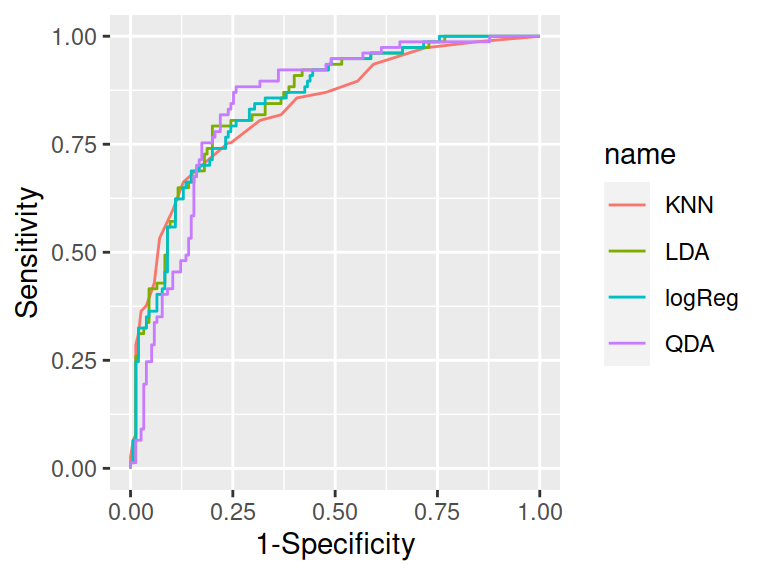

```r
probs = data.frame(diabetes = test$diabetes, logReg = predLogistic, LDA = postLDA[, 2], QDA = postQDA[, 2], KNN = probKNN)
plProbs = melt_roc(probs, "diabetes", c("logReg", "LDA", "QDA", "KNN"))
ggplot(plProbs, aes(d = D, m = M, color = name)) + geom_roc(n.cuts = F, size = 0.5) + xlab("1-Specificity") + ylab("Sensitivity")
```

```r
aucAll = data.frame(auc = c(auc(logReg.ROC), auc(LDA.ROC), auc(QDA.ROC), auc(KNN.ROC)))
rownames(aucAll) = c("logReg", "LDA", "QDA", "KNN")
kableExtra::kable(aucAll)
```

|  | auc |
| --- | --- |
| logReg | 0.8450775 |
| LDA | 0.8490155 |
| QDA | 0.8414747 |
| KNN | 0.8325513 |

# Problem 4

## a)

See notes.

## b)

### i)

FALSE

### ii)

TRUE

### iii)

FALSE

### iv)

FALSE

# Problem 5

```r
id <- "19auu8YlUJJJUsZY8JZfsCTWzDm6doE7C"  # google file ID
d.bodyfat <- read.csv(sprintf("https://docs.google.com/uc?id=%s&export=download",
    id), header = T)
```

## a)

```r
r.lm <- lm(bodyfat ~ age + weight + bmi, data = d.bodyfat)
summary(r.lm)$r.squared
```

```
## [1] 0.5803041
```

## b)

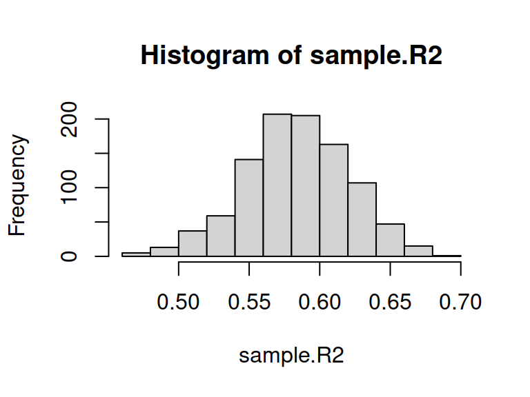

```r
set.seed(4268)
B <- 1000
sample.R2 <- rep(NA, B)
for (ii in 1:B) {
  d.boot <- d.bodyfat[sample(1:nrow(d.bodyfat), size = nrow(d.bodyfat), replace = TRUE), ]
  r.lm.boot <- lm(bodyfat ~ age + weight + bmi, data = d.boot)
  sample.R2[ii] <- summary(r.lm.boot)$r.squared
}
hist(sample.R2)
```

```r
sd(sample.R2)
```

```
## [1] 0.03705002
```

```r
quantile(sample.R2, c(0.025, 0.975))
```

```
##      2.5%     97.5%
## 0.5090717 0.6534133
```

There is uncertainty in $R^2$, although that is usually not visible/reported in the summary output.